# Journal Club: Best Practices for Scientific Computing

15/02/2023

## HOW TO (RE-)USE THIS MATERIAL

This is a `.html` presentation created in `R Markdown` with `ioslides`.

(It’s been written in a [.Rmd](http://rmarkdown.rstudio.com) file, and I generated .html slides by ‘knitting’ it in Rstudio.)

You can check out the code used to make these slides at the [Talk repo](https://github.com/FlicAnderson/20230215-JournalClub-BestPractices/) on Github, and adapt it for your own presentations if you like - there’s a MIT Licence on the repo, which means:

*“Basically, you can do whatever you want as long as you include the original copyright and license notice in any copy of the software/source.”*

Source: [tl;drLegal](https://tldrlegal.com/license/mit-license)

## Outline

**Article:**  
- Paper format  
- Background / research context  
- Paper’s aims  
- Best Practices  
- Authors’ conclusions

**Discussion & Qs:**  
- My opinions about the paper  
- Your questions about the paper  
- Discussion - which best practice do you think is most important?

**RS: Research software**  
**SE: Software engineering**

## The Article

[figure not shown]

## Paper Format

- presenting **8 broad best practice tips** & *24 recommendations*
- no abstract / methods / research Qs
- reasonably informal paper, **accessible and readable**
- *influenced my career*

## Background / Research Context

- article **published 2014** @ *PLOS Biology*
- [Wilson 2006](https://doi.org/10.1109/MCSE.2006.122) paper “Software Carpentry: getting scientists to write better code by making them more productive”
- [Heroux & Willenbring 2009](https://doi.org/10.1109/SECSE.2009.5069157) “Barely sufficient software engineering: 10 practices to improve your CSE software”
- [Kelly, Hook & Sanders 2009](https://doi.org/10.1109/MCSE.2009.139) “Five Recommended Practices for Computational Scientists Who Write Software”
- Carpentries’ reports (2004+) gathered data from foundational programming/data skills *workshop evaluations*
- discusses **scientific computing**, but applies widely to *any software for generating research outputs*

## MY Background/ Research Context

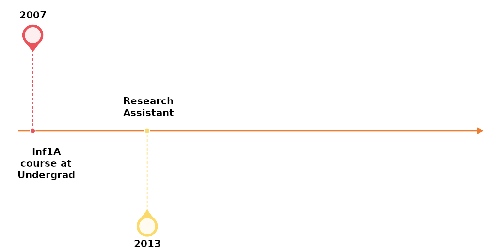

## Paper’s Aims

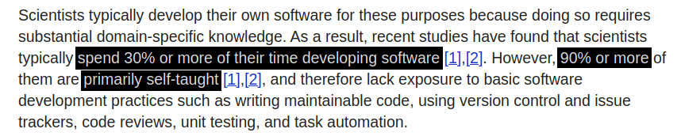

- authors’ goals in sharing these best practices:
  - **faster development** of RS, results
  - code is more **reliable**, inspires confidence in results
  - **reproducibility** of results
- justifies importance in terms of **reducing errors/retractions**; *improving productivity*

1 - **Write programs for people, not computers**

2 - **Let the computer do the work**

3 - **Make incremental changes**

4 - **Don’t repeat yourself (or others)**

5 - **Plan for mistakes**

6 - **Optimise software only after it works correctly**

7 - **Document design and purpose, not mechanics**

8 - **Collaborate**

‘Best Practices for Scientific Computing’, [Wilson et al. 2014.](https://doi.org/10.1371/journal.pbio.1001745)

## 1. Write programs for people, not computers

- *beware memory limits* in users, not just computers: reduce cognitive load!
  - **break up programs** into *task-oriented functions* or chunks
- self documenting **descriptive names**
- **consistent_styling_of_code** -> faster reading, fewer errors

## 2. Let the computer do the work

- **CLI** commands & tasks -> **scripts**
- **automate workflows** with a *Workflow Management System* or *build tool* like [Make](https://www.gnu.org/software/make/#:~:text=GNU%20Make%20is%20a%20tool,compute%20it%20from%20other%20files.)
- **store provenance info** (common file formats plz):
  - raw data IDs, version numbers
  - *parameter* values generating specific outputs
  - *library/program versions*
- cite your software!

WfMS examples: [nextflow](https://www.nextflow.io/), [snakemake](https://snakemake.readthedocs.io/en/stable/)

## 3. Make incremental changes

- RS uses an *iterate-improve* process; similar to Agile development process
  - *no ‘requirements’ available* upfront for RS
- **keep iterations SHORT** (~1 week), get feedback, improve
- use **version control system** for code AND data
  - **vc manually created things**…
  - *regenerate* the rest (archive binaries, store metadata)

## 4. Don’t repeat yourself (or others)

- *copies of data / ‘code clones’ is bad*
- **only one version of a file / variable / ID** that can be updated in ONE PLACE ONLY
- write IKEA code but avoid DIY:
  - **modularity** -> fixable, reusable and easy to remember (*mental model* of code)
  - **use others’ libraries and packages**

## Update…

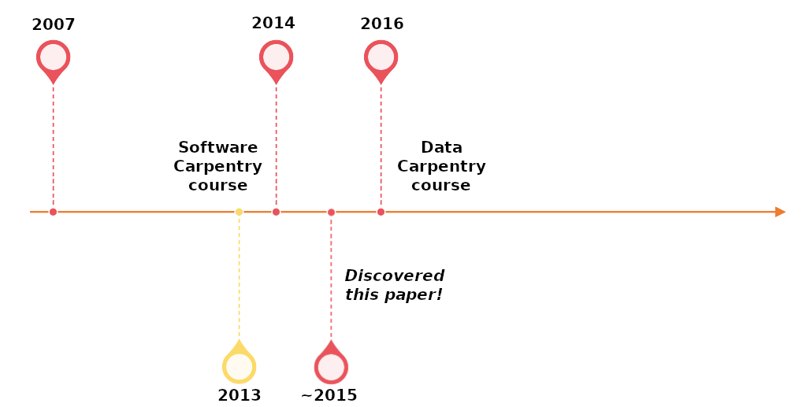

## 5. Plan for mistakes

- *defensive programming*: **use assertions** in your code
- run *automated testing* with **testing libraries**
- **turn bugs into tests** (prevents silent reappearance of ‘fixed’ issues) for RS
- **use debuggers**

## 6. Optimise software only after it works correctly

- **write, profile THEN fix** performance bottlenecks
- **write high-level code**:
  - more efficient *per line of code per unit of time*
  - more understandable / self-documenting
  - prototype in high-level languages, THEN implement optimised versions

## 7. Document design and purpose, not mechanics

- share knowledge *(bus factor!)*
- **explain design decisions**
- **refactor** instead of trying to explain complex code
- *documentation generators*: **embed docs** into code (Try [Sphinx](https://docs.readthedocs.io/en/stable/intro/getting-started-with-sphinx.html))
- *“literate programming”* - code into docs! ([Jupyter Notebooks](https://jupyter.org/) for Python+)

## 8. Collaborate

- “code review: *get other people to read your code to find bugs fast & cheap!“* - says decades of research
  - require review **before merging**!
- **pair programming** for complex coding tasks or onboarding new folks to project
- use **issue tracking** (eg. Github)
- your future self…

## Authors’ Conclusions

- useful for **solo coders or multi-dev RS teams**
- **add practices gradually**; overlap helps
- scientists need to start adopting tools and approaches to **improve quality & efficiency** of software
  - time costs offset “almost immediately” by productivity gains
- *universities / funders must support researchers* to write better software

## This Paper Might Change Your Career…

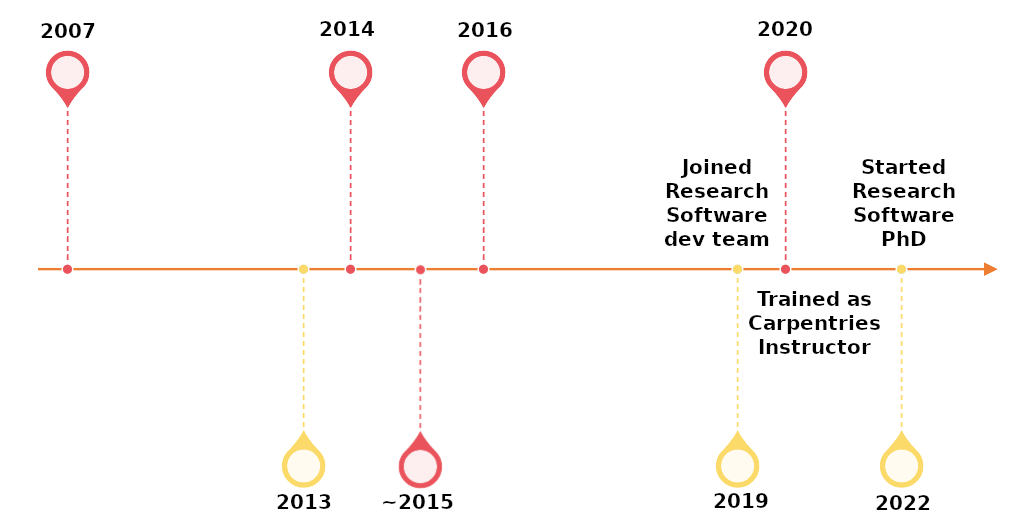

## Opinions, Discussion, Qs…

## My Opinions

- well-written, supports aims of the paper: **successful!**
- **explains SE concepts well** to non-specialists
- **escalating order** of recommendations
- *possibly off-putting* to extreme novices/experts? (e.g. optimisation/profiling)
- Wilson et al. 2017: [Good Enough Practices in Scientific Computing](https://doi.org/10.1371/journal.pcbi.1005510) in PLOS Computational Biology

Q: did publishing in PLOS Biology limit reach into other fields?

## Reminder of Best Practices

1 - **Write programs for people, not computers**

2 - **Let the computer do the work**

3 - **Make incremental changes**

4 - **Don’t repeat yourself (or others)**

5 - **Plan for mistakes**

6 - **Optimise software only after it works correctly**

7 - **Document design and purpose, not mechanics**

8 - **Collaborate**

‘Best Practices for Scientific Computing’, [Wilson et al. 2014.](https://doi.org/10.1371/journal.pbio.1001745)